# Lab 6- Variable Selection and Regularization

### Lasso Regression: Using only the one best numeric variable - ‘CRuns’

```python
X = baseball[['CRuns']]
y = baseball['Salary']

ct = ColumnTransformer(
  [
    ("dummify",OneHotEncoder(sparse_output = False, handle_unknown='ignore'),
    make_column_selector(dtype_include=object)),("standardize",StandardScaler(),
    make_column_selector(dtype_include=np.number))
  ],
  remainder = "passthrough"
)

lasso_pipeline = Pipeline([('preprocessor', ct),
                          ('regressor', Lasso())])

lasso_pipeline.fit(X, y)

alpha_values = [0.001, 0.01, 0.1, 1, 10]

alpha_grid = {'regressor__alpha': alpha_values}

gscv = GridSearchCV(lasso_pipeline, alpha_grid, cv = 5, scoring='neg_mean_squared_error')

gscv_fitted = gscv.fit(X, y)

results = gscv_fitted.cv_results_['mean_test_score']

results = - results

# Get the coefficients of the linear regression model
coefs_lasso = lasso_pipeline.named_steps["regressor"].coef_

scores = cross_val_score(lasso_pipeline, X, y, cv = 5, scoring = 'neg_mean_squared_error')

-scores
```

```
array([ 62249.34278589, 232426.33067421, 131564.59703961, 205601.95663267,
        87165.80328794])
```

```python
lasso_mean_mse = -scores.mean()

lasso_mean_mse
```

```
143801.6060840633
```

```python
pd.DataFrame(data = {"alpha": [0.001, 0.01, 0.1, 1, 10], "scores": results}).sort_values(by="scores", ascending = True)
```

|  | alpha | scores |
| --- | --- | --- |
| 4 | 10.000 | 143793.449159 |
| 3 | 1.000 | 143801.606084 |
| 2 | 0.100 | 143811.709122 |
| 1 | 0.010 | 143812.812299 |
| 0 | 0.001 | 143812.923545 |

**Chosen lambda = 10 After tuning**

```python
lasso_pipeline2 = Pipeline([('preprocessor', ct),
                          ('regressor', Lasso(alpha=10))])

model_lasso2 = lasso_pipeline2.fit(X, y)

# Get the coefficients of the chosen ridge regression model
coefs_lasso2 = lasso_pipeline2.named_steps["regressor"].coef_

coefs_lasso2
```

```
array([243.3513921])
```

```python
scores = cross_val_score(lasso_pipeline2, X, y, cv = 5, scoring = 'neg_mean_squared_error')

lasso_mean_mse2 = -scores.mean()

lasso_mean_mse2
```

```
143793.4491585397
```

### Elastic Net Regression: Using only the best numeric variable - ‘CRuns’

```python
X = baseball[['CRuns']]
y = baseball['Salary']

ct = ColumnTransformer(
  [
    ("dummify",OneHotEncoder(sparse_output = False, handle_unknown='ignore'),
    make_column_selector(dtype_include=object)),("standardize",StandardScaler(),
    make_column_selector(dtype_include=np.number))
  ],
  remainder = "passthrough"
)

elasticnet_pipeline = Pipeline(steps=[('preprocessor', ct),
                                      ('regressor', ElasticNet())])

# l1_ratio values
l1_ratio_values = [0.2, 0.4, 0.6, 0.8, 1]

# Set up the grid search with Elastic Net within a pipeline
param_grid = {
    'regressor__alpha': alpha_values,
    'regressor__l1_ratio': l1_ratio_values}

elasticnet_gscv = GridSearchCV(elasticnet_pipeline, param_grid, cv=5, scoring='neg_mean_squared_error')

model_elasticnet = elasticnet_pipeline.fit(X, y)

elasticnet_fitted = elasticnet_gscv.fit(X, y)

results = elasticnet_fitted.cv_results_['mean_test_score']
results = -results

alphas = elasticnet_fitted.cv_results_['param_regressor__alpha']
lambdas = elasticnet_fitted.cv_results_['param_regressor__l1_ratio']

pd.DataFrame(data = {"alpha": alphas,"l1_ratio": lambdas, "scores": results}).sort_values(by="scores", ascending = True)
```

|  | alpha | l1_ratio | scores |
| --- | --- | --- | --- |
| 11 | 0.1 | 0.4 | 143660.021761 |
| 12 | 0.1 | 0.6 | 143661.305279 |
| 10 | 0.1 | 0.2 | 143700.990508 |
| 13 | 0.1 | 0.8 | 143709.955158 |
| 5 | 0.01 | 0.2 | 143764.957824 |
| 6 | 0.01 | 0.4 | 143776.051565 |
| 7 | 0.01 | 0.6 | 143787.720788 |
| 24 | 10 | 1 | 143793.449159 |
| 8 | 0.01 | 0.8 | 143799.972129 |
| 19 | 1 | 1 | 143801.606084 |
| 0 | 0.001 | 0.2 | 143807.712481 |
| 1 | 0.001 | 0.4 | 143809.006335 |
| 2 | 0.001 | 0.6 | 143810.306126 |
| 3 | 0.001 | 0.8 | 143811.611861 |
| 14 | 0.1 | 1 | 143811.709122 |
| 9 | 0.01 | 1 | 143812.812299 |
| 4 | 0.001 | 1 | 143812.923545 |
| 18 | 1 | 0.8 | 144667.216774 |
| 17 | 1 | 0.6 | 147576.632662 |
| 16 | 1 | 0.4 | 151011.652217 |
| 15 | 1 | 0.2 | 154425.827508 |
| 23 | 10 | 0.8 | 170752.854658 |
| 22 | 10 | 0.6 | 182831.204561 |
| 21 | 10 | 0.4 | 188689.932969 |
| 20 | 10 | 0.2 | 192121.672794 |

**Chosen lambda = 0.1, chosen l1_ratio = 0.4 after tuning**

```python
elasticnet_pipeline2 = Pipeline([('preprocessor', ct),
                          ('regressor', ElasticNet(alpha=0.1, l1_ratio = 0.4))])

model_elastic2 = elasticnet_pipeline2.fit(X, y)

# Get the coefficients of the chosen ridge regression model
coefs_elastic2  = elasticnet_pipeline2.named_steps["regressor"].coef_

coefs_elastic2
```

```
array([238.97301141])
```

```python
scores = cross_val_score(elasticnet_pipeline2, X, y, cv = 5, scoring = 'neg_mean_squared_error')

elasticnet_mean_mse2 = -scores.mean()

elasticnet_mean_mse2
```

```
143660.02176060158
```

### Regression without Regularization: Using only the five best variables.

```python
X_top5 = baseball[['CRuns', 'Hits', 'AtBat', 'CRBI', 'CAtBat']]
y = baseball['Salary']

ct = ColumnTransformer(
  [
    ("dummify",OneHotEncoder(sparse_output = False, handle_unknown='ignore'),
    make_column_selector(dtype_include=object)),("standardize",StandardScaler(),
    make_column_selector(dtype_include=np.number))
  ],
  remainder = "passthrough"
)

lr_pipeline = Pipeline(
  [("preprocessing", ct),
  ("linear_regression", LinearRegression())]
)

lr_model = lr_pipeline.fit(X_top5,y)


# Get the coefficients of the linear regression model
coefs_linear_top5 = lr_pipeline.named_steps["linear_regression"].coef_
coefs_linear_top5
```

```
array([ 374.17935592,  333.8490185 , -206.2074796 ,  241.44832184,
       -386.6578981 ])
```

```python
scores = cross_val_score(lr_pipeline, X, y, cv = 5, scoring = 'neg_mean_squared_error')

-scores
```

```
array([ 62274.55517261, 232350.62052393, 131318.6494137 , 206031.6119594 ,
        87089.24251184])
```

```python
lr_mean_mse_top5 = -scores.mean()

lr_mean_mse_top5
```

```
143812.9359162973
```

### Ridge Regression: Using only the five best variables.

```python
ridge_pipeline = Pipeline([('preprocessor', ct),('regressor', Ridge())])

ridge_pipeline.fit(X_top5, y)

alpha_values = [0.001, 0.01, 0.1, 1, 10]

alpha_grid = {'regressor__alpha': alpha_values}

gscv = GridSearchCV(ridge_pipeline, alpha_grid, cv = 5, scoring='neg_mean_squared_error')

gscv_fitted = gscv.fit(X_top5, y)

results = gscv_fitted.cv_results_['mean_test_score']

results = - results

# Get the coefficients of the linear regression model
coefs_ridge = ridge_pipeline.named_steps["regressor"].coef_
coefs_ridge

scores = cross_val_score(ridge_pipeline, X_top5, y, cv = 5, scoring = 'neg_mean_squared_error')

-scores

pd.DataFrame(data = {"alpha": alpha_values, "scores": results}).sort_values(by="scores", ascending = True)
```

|  | alpha | scores |
| --- | --- | --- |
| 3 | 1.000 | 120858.260458 |
| 2 | 0.100 | 121146.294499 |
| 1 | 0.010 | 121219.357981 |
| 0 | 0.001 | 121227.324808 |
| 4 | 10.000 | 123262.257202 |

**Chosen lambda = 1 after tuning**

```python
ridge_pipeline2 = Pipeline([('preprocessor', ct),
                          ('regressor', Ridge(alpha=1))])

model_ridge2 = ridge_pipeline2.fit(X_top5, y)

# Get the coefficients of the chosen ridge regression model
coefs_ridge2_top5 = ridge_pipeline2.named_steps["regressor"].coef_

coefs_ridge2_top5
```

```
array([ 309.82600866,  310.6083936 , -180.75415282,  227.47480404,
       -309.42303848])
```

```python
scores = cross_val_score(ridge_pipeline2, X_top5, y, cv = 5, scoring = 'neg_mean_squared_error')

ridge_mse_top5 = -scores.mean()

ridge_mse_top5
```

```
120858.26045820327
```

### Lasso Regression: Using only the five best variables.

```python
lasso_pipeline = Pipeline([('preprocessor', ct),
                          ('regressor', Lasso())])

lasso_pipeline.fit(X_top5, y)

alpha_values = [0.001, 0.01, 0.1, 1, 10]

alpha_grid = {'regressor__alpha': alpha_values}

gscv = GridSearchCV(lasso_pipeline, alpha_grid, cv = 5, scoring='neg_mean_squared_error')

gscv_fitted = gscv.fit(X_top5, y)

results = gscv_fitted.cv_results_['mean_test_score']

results = - results

# Get the coefficients of the linear regression model
coefs_lasso = lasso_pipeline.named_steps["regressor"].coef_

scores = cross_val_score(lasso_pipeline, X_top5, y, cv = 5, scoring = 'neg_mean_squared_error')

-scores

pd.DataFrame(data = {"alpha": alpha_values, "scores": results}).sort_values(by="scores", ascending = True)
```

|  | alpha | scores |
| --- | --- | --- |
| 0 | 0.001 | 121228.325531 |
| 1 | 0.010 | 121229.305334 |
| 2 | 0.100 | 121239.691817 |
| 3 | 1.000 | 121519.069726 |
| 4 | 10.000 | 126840.365715 |

**Chosen lambda = 0.001 after tuning**

```python
lasso_pipeline2 = Pipeline([('preprocessor', ct),
                          ('regressor', Lasso(alpha=0.001))])

model_lasso2 = lasso_pipeline2.fit(X, y)

# Get the coefficients of the chosen ridge regression model
coefs_lasso2_top_5 = lasso_pipeline2.named_steps["regressor"].coef_

coefs_lasso2_top_5
```

```
array([253.3503921])
```

```python
scores = cross_val_score(lasso_pipeline2, X_top5, y, cv = 5, scoring = 'neg_mean_squared_error')

lasso_mse_top5 = -scores.mean()
lasso_mse_top5
```

```
121228.32553085312
```

### Elastic Net Regression: Using only the five best variables.

```python
elasticnet_pipeline = Pipeline(steps=[('preprocessor', ct),
                                      ('regressor', ElasticNet())])

# l1_ratio values
l1_ratio_values = [0.2, 0.4, 0.6, 0.8, 1]

# Set up the grid search with Elastic Net within a pipeline
param_grid = {
    'regressor__alpha': alpha_values,
    'regressor__l1_ratio': l1_ratio_values}

elasticnet_gscv = GridSearchCV(elasticnet_pipeline, param_grid, cv=5, scoring='neg_mean_squared_error')

model_elasticnet = elasticnet_pipeline.fit(X_top5, y)

elasticnet_fitted = elasticnet_gscv.fit(X_top5, y)

results = elasticnet_fitted.cv_results_['mean_test_score']
results = -results

alphas = elasticnet_fitted.cv_results_['param_regressor__alpha']
lambdas = elasticnet_fitted.cv_results_['param_regressor__l1_ratio']

pd.DataFrame(data = {"alpha": alphas,"l1_ratio": lambdas, "scores": results}).sort_values(by="scores", ascending = True)
```

|  | alpha | l1_ratio | scores |
| --- | --- | --- | --- |
| 6 | 0.01 | 0.4 | 120862.769648 |
| 7 | 0.01 | 0.6 | 120867.652433 |
| 5 | 0.01 | 0.2 | 120916.135770 |
| 8 | 0.01 | 0.8 | 120967.819425 |
| 0 | 0.001 | 0.2 | 121097.330756 |
| 1 | 0.001 | 0.4 | 121126.457929 |
| 2 | 0.001 | 0.6 | 121157.905351 |
| 3 | 0.001 | 0.8 | 121191.810431 |
| 4 | 0.001 | 1 | 121228.325531 |
| 9 | 0.01 | 1 | 121229.305334 |
| 14 | 0.1 | 1 | 121239.691817 |
| 19 | 1 | 1 | 121519.069726 |
| 13 | 0.1 | 0.8 | 121715.354632 |
| 12 | 0.1 | 0.6 | 122927.735174 |
| 11 | 0.1 | 0.4 | 123808.583967 |
| 10 | 0.1 | 0.2 | 124443.399353 |
| 18 | 1 | 0.8 | 126315.055828 |
| 24 | 10 | 1 | 126840.365715 |
| 17 | 1 | 0.6 | 127579.916651 |
| 16 | 1 | 0.4 | 128629.727483 |
| 15 | 1 | 0.2 | 129764.317887 |
| 23 | 10 | 0.8 | 139446.904380 |
| 22 | 10 | 0.6 | 151749.823579 |
| 21 | 10 | 0.4 | 160579.655823 |
| 20 | 10 | 0.2 | 166963.969915 |

**Chosen lambda = 0.01, chosen l1_ratio = 0.4 after tuning**

```python
elasticnet_pipeline2 = Pipeline([('preprocessor', ct),
                          ('regressor', ElasticNet(alpha=0.01, l1_ratio = 0.4))])

model_elastic2 = elasticnet_pipeline2.fit(X_top5, y)

# Get the coefficients of the chosen ridge regression model
coefs_elastic2  = elasticnet_pipeline2.named_steps["regressor"].coef_

coefs_elastic2
```

```
array([ 282.76159908,  298.67542578, -167.9083094 ,  220.65086436,
       -276.04901498])
```

```python
scores = cross_val_score(elasticnet_pipeline2, X_top5, y, cv = 5, scoring = 'neg_mean_squared_error')

elasticnet_mean_mse_top5 = -scores.mean()

elasticnet_mean_mse_top5
```

```
120862.76964842975
```

```python
model_elasticnet = elasticnet_pipeline2.fit(X_top5, y)

elasticnet_fitted = elasticnet_gscv.fit(X_top5, y)

results = elasticnet_fitted.cv_results_['mean_test_score']
```

```python
results = -results
results
```

```
array([121097.3307564 , 121126.45792929, 121157.90535072, 121191.81043109,
       121228.32553085, 120916.13576989, 120862.76964843, 120867.6524326 ,
       120967.8194247 , 121229.30533369, 124443.39935295, 123808.58396672,
       122927.73517438, 121715.35463152, 121239.69181747, 129764.31788695,
       128629.72748266, 127579.91665057, 126315.05582764, 121519.0697265 ,
       166963.96991526, 160579.65582302, 151749.82357893, 139446.90438016,
       126840.36571538])
```

### Regression without Regularization: Using the five best numeric variables and their interactions with the one best categorical variable.

```python
# printing all the unique values in the Division column
baseball["Division"].unique()
```

```
array(['W', 'E'], dtype=object)
```

```python
X = baseball[['CRuns', 'Hits', 'AtBat', 'CRBI', 'CAtBat', 'Division']]
y = baseball['Salary']

ct = ColumnTransformer(
    [("dummify", OneHotEncoder(sparse_output=False), ["Division"])],
    remainder="passthrough").set_output(transform = "pandas")

ct_inter = ColumnTransformer(
  [ ("interaction1", PolynomialFeatures(interaction_only = True), ["remainder__CRuns", "dummify__Division_W"]),
    ("interaction2", PolynomialFeatures(interaction_only = True), ["remainder__CRuns", "dummify__Division_E"]),
    ("interaction3", PolynomialFeatures(interaction_only = True), ["remainder__Hits", "dummify__Division_W"]),
    ("interaction4", PolynomialFeatures(interaction_only = True), ["remainder__Hits", "dummify__Division_E"]),
    ("interaction5", PolynomialFeatures(interaction_only = True), ["remainder__AtBat", "dummify__Division_W"]),
    ("interaction6", PolynomialFeatures(interaction_only = True), ["remainder__AtBat", "dummify__Division_E"]),
    ("interaction7", PolynomialFeatures(interaction_only = True), ["remainder__CRBI", "dummify__Division_W"]),
    ("interaction8", PolynomialFeatures(interaction_only = True), ["remainder__CRBI", "dummify__Division_E"]),
    ("interaction9", PolynomialFeatures(interaction_only = True), ["remainder__CAtBat", "dummify__Division_W"]),
    ("interaction10", PolynomialFeatures(interaction_only = True), ["remainder__CAtBat", "dummify__Division_E"]),
  ],remainder = "drop").set_output(transform = "pandas")

lr_pipeline = Pipeline(
  [("dummifying", ct), ("interaction", ct_inter),
  ("linear_regression", LinearRegression())]
)

lr_model = lr_pipeline.fit(X,y)

# Get the coefficients of the linear regression model
coefs_linear_interaction = lr_pipeline.named_steps["linear_regression"].coef_
coefs_linear_interaction
```

```
array([-7.01476438e-13,  3.35091364e-01, -2.11578522e+01, -3.99995662e-01,
       -1.03583808e-13,  3.35091364e-01,  2.11578522e+01,  7.35087026e-01,
       -6.07291994e-14,  2.51447193e+00, -2.11578522e+01, -2.53950761e+00,
        0.00000000e+00,  2.51447193e+00,  2.11578522e+01,  5.05397954e+00,
        0.00000000e+00, -4.68097433e-01, -2.11578522e+01,  9.47729183e-01,
        0.00000000e+00, -4.68097433e-01,  2.11578522e+01, -1.41582662e+00,
        0.00000000e+00,  3.19031032e-01, -2.11578522e+01, -3.79029165e-01,
        0.00000000e+00,  3.19031032e-01,  2.11578522e+01,  6.98060197e-01,
        0.00000000e+00, -5.37618153e-02, -2.11578522e+01,  1.09082391e-01,
        0.00000000e+00, -5.37618153e-02,  2.11578522e+01, -1.62844207e-01])
```

**Using cross-validation to estimate the MSE you would expect if you used this pipeline to predict salaries using ‘CRuns’, ‘Hits’, ‘AtBat’, ‘CRBI’, ‘CAtBat’ and their interaction with ‘Division’.**

```python
scores = cross_val_score(lr_pipeline, X, y, cv = 5, scoring = 'neg_mean_squared_error')

-scores
```

```
array([ 61415.17291111, 157797.79280027,  84882.81674863, 243039.90896797,
        88862.87287108])
```

```python
lr_mean_mse_interaction = -scores.mean()

lr_mean_mse_interaction
```

```
127199.71285981321
```

### Ridge Regression: Using the five best numeric variables and their interactions with the one best categorical variable.

```python
X = baseball[['CRuns', 'Hits', 'AtBat', 'CRBI', 'CAtBat', 'Division']]
y = baseball['Salary']

ridge_pipeline = Pipeline([("dummifying", ct), ("interaction", ct_inter),('regressor', Ridge())])

ridge_pipeline.fit(X,y)

alpha_values = [0.001, 0.01, 0.1, 1, 10]

alpha_grid = {'regressor__alpha': alpha_values}

gscv = GridSearchCV(ridge_pipeline, alpha_grid, cv = 5, scoring='neg_mean_squared_error')

gscv_fitted = gscv.fit(X,y)

results = gscv_fitted.cv_results_['mean_test_score']

results = - results

# Get the coefficients of the ridge regression model
coefs_ridge = ridge_pipeline.named_steps["regressor"].coef_
coefs_ridge

scores = cross_val_score(ridge_pipeline, X,y, cv = 5, scoring = 'neg_mean_squared_error')

-scores

pd.DataFrame(data = {"alpha": alpha_values, "scores": results}).sort_values(by="scores", ascending = True)
```

|  | alpha | scores |
| --- | --- | --- |
| 4 | 10.000 | 127072.162586 |
| 3 | 1.000 | 127181.000313 |
| 2 | 0.100 | 127197.762474 |
| 1 | 0.010 | 127199.517005 |
| 0 | 0.001 | 127199.693266 |

**Chosen lambda = 10 after tuning.**

```python
ridge_pipeline2 = Pipeline([('preprocessor', ct), ("interaction", ct_inter),('regressor', Ridge(alpha=10))])

model_ridge2 = ridge_pipeline2.fit(X, y)

# Get the coefficients of the chosen ridge regression model
coefs_ridge2_interaction = ridge_pipeline2.named_steps["regressor"].coef_

coefs_ridge2_interaction
```

```
array([  0.        ,   0.33474634, -18.22674687,  -0.38521722,
         0.        ,   0.33474634,  18.22674687,   0.71996356,
         0.        ,   2.50971056, -18.22674687,  -2.43219476,
         0.        ,   2.50971056,  18.22674687,   4.94190532,
         0.        ,  -0.46628359, -18.22674687,   0.89002651,
         0.        ,  -0.46628359,  18.22674687,  -1.3563101 ,
         0.        ,   0.31769279, -18.22674687,  -0.37420119,
         0.        ,   0.31769279,  18.22674687,   0.69189398,
         0.        ,  -0.05350735, -18.22674687,   0.10594551,
         0.        ,  -0.05350735,  18.22674687,  -0.15945291])
```

```python
scores = cross_val_score(ridge_pipeline2, X, y, cv = 5, scoring = 'neg_mean_squared_error')

ridge_mse_interaction = -scores.mean()

ridge_mse_interaction
```

```
127072.16258575942
```

### Lasso Regression: Using the five best numeric variables and their interactions with the one best categorical variable.

```python
lasso_pipeline = Pipeline([("dummifying", ct), ("interaction", ct_inter),('regressor', Lasso())])


lasso_pipeline.fit(X, y)

alpha_values = [0.001, 0.01, 0.1, 1, 10]

alpha_grid = {'regressor__alpha': alpha_values}

gscv = GridSearchCV(lasso_pipeline, alpha_grid, cv = 5, scoring='neg_mean_squared_error')

gscv_fitted = gscv.fit(X, y)

results = gscv_fitted.cv_results_['mean_test_score']

results = - results

# Get the coefficients of the linear regression model
coefs_lasso = lasso_pipeline.named_steps["regressor"].coef_

scores = cross_val_score(lasso_pipeline, X, y, cv = 5, scoring = 'neg_mean_squared_error')

-scores

pd.DataFrame(data = {"alpha": alpha_values, "scores": results}).sort_values(by="scores", ascending = True)
```

|  | alpha | scores |
| --- | --- | --- |
| 1 | 0.010 | 127176.914953 |
| 0 | 0.001 | 127195.799714 |
| 2 | 0.100 | 127215.975727 |
| 3 | 1.000 | 127345.361998 |
| 4 | 10.000 | 127464.696045 |

**Chosen lambda = 0.010 after tuning.**

```python
lasso_pipeline2 = Pipeline([('preprocessor', ct), ("interaction", ct_inter),
                          ('regressor', Lasso(alpha=0.010))])

model_lasso2 = lasso_pipeline2.fit(X, y)

# Get the coefficients of the chosen ridge regression model
coefs_lasso2_interaction = lasso_pipeline2.named_steps["regressor"].coef_

coefs_lasso2_interaction
```

```
array([ 0.00000000e+00,  6.19663229e-01, -4.87167988e+02, -6.92054815e-01,
        0.00000000e+00,  3.42206074e-01, -1.70040831e+02,  4.41577308e-01,
        0.00000000e+00,  5.05538467e+00,  2.04396258e+02, -4.25026160e+00,
        0.00000000e+00,  1.70071145e+00, -4.55420156e+02,  3.30986164e+00,
        0.00000000e+00, -8.72744247e-01,  3.55088227e+02,  1.36931784e+00,
        0.00000000e+00, -4.89698576e-01,  4.69751223e+02, -9.84205270e-01,
        0.00000000e+00,  5.49671948e-01, -3.97923921e+02, -6.39234216e-01,
        0.00000000e+00,  3.48633105e-01, -1.31754314e+02,  4.37131715e-01,
        0.00000000e+00, -5.96924676e-02,  1.42462151e+02,  1.48318964e-01,
        0.00000000e+00, -8.70187365e-02,  3.15348327e+02, -1.23285111e-01])
```

```python
scores = cross_val_score(lasso_pipeline2, X, y, cv = 5, scoring = 'neg_mean_squared_error')

lasso_mse_interaction = -scores.mean()

lasso_mse_interaction
```

```
127176.91495345868
```

### Elastic Net Regression: Using the five best numeric variables and their interactions with the one best categorical variable.

```python
elasticnet_pipeline = Pipeline([("dummifying", ct), ("interaction", ct_inter),('regressor', ElasticNet())])

# l1_ratio values
l1_ratio_values = [0.2, 0.4, 0.6, 0.8, 1]

# Set up the grid search with Elastic Net within a pipeline
param_grid = {
    'regressor__alpha': alpha_values,
    'regressor__l1_ratio': l1_ratio_values}

elasticnet_gscv = GridSearchCV(elasticnet_pipeline, param_grid, cv=5, scoring='neg_mean_squared_error')

model_elasticnet = elasticnet_pipeline.fit(X, y)

elasticnet_fitted = elasticnet_gscv.fit(X, y)

results = elasticnet_fitted.cv_results_['mean_test_score']
results = -results

alphas = elasticnet_fitted.cv_results_['param_regressor__alpha']
lambdas = elasticnet_fitted.cv_results_['param_regressor__l1_ratio']

pd.DataFrame(data = {"alpha": alphas,"l1_ratio": lambdas, "scores": results}).sort_values(by="scores", ascending = True)
```

|  | alpha | l1_ratio | scores |
| --- | --- | --- | --- |
| 10 | 0.1 | 0.2 | 127037.379443 |
| 11 | 0.1 | 0.4 | 127060.202159 |
| 12 | 0.1 | 0.6 | 127093.263754 |
| 3 | 0.001 | 0.8 | 127116.507396 |
| 13 | 0.1 | 0.8 | 127140.786473 |
| 2 | 0.001 | 0.6 | 127141.541986 |
| 7 | 0.01 | 0.6 | 127159.095501 |
| 18 | 1 | 0.8 | 127160.566844 |
| 5 | 0.01 | 0.2 | 127169.445910 |
| 17 | 1 | 0.6 | 127171.732098 |
| 9 | 0.01 | 1 | 127176.914953 |
| 6 | 0.01 | 0.4 | 127181.671173 |
| 16 | 1 | 0.4 | 127193.352994 |
| 4 | 0.001 | 1 | 127195.799714 |
| 1 | 0.001 | 0.4 | 127202.632106 |
| 15 | 1 | 0.2 | 127211.161393 |
| 14 | 0.1 | 1 | 127215.975727 |
| 8 | 0.01 | 0.8 | 127226.676956 |
| 0 | 0.001 | 0.2 | 127264.043502 |
| 20 | 10 | 0.2 | 127313.480614 |
| 19 | 1 | 1 | 127345.361998 |
| 21 | 10 | 0.4 | 127365.854171 |
| 22 | 10 | 0.6 | 127408.042144 |
| 23 | 10 | 0.8 | 127441.081471 |
| 24 | 10 | 1 | 127464.696045 |

**Chosen lambda = 0.1, chosen l1_ratio = 0.2 after tuning**

```python
elasticnet_pipeline2 = Pipeline([('preprocessor', ct), ("interaction", ct_inter),
                          ('regressor', ElasticNet(alpha=0.1, l1_ratio = 0.2))])

model_elastic2 = elasticnet_pipeline2.fit(X, y)

# Get the coefficients of the chosen ridge regression model
coefs_elastic2  = elasticnet_pipeline2.named_steps["regressor"].coef_

coefs_elastic2
```

```
array([  0.        ,   0.65614115, -15.7457334 ,  -0.78784867,
         0.        ,   0.42792328,  15.74685771,   0.291996  ,
         0.        ,   6.82142105, -15.75263177,  -6.70560473,
         0.        ,   2.55268975,  15.81020432,   0.48798269,
         0.        ,  -1.25711583, -15.74408688,   1.9810154 ,
         0.        ,  -0.81177947,  15.74025827,  -0.16764935,
         0.        ,   0.58244088, -15.74589394,  -0.73546572,
         0.        ,   0.41602412,  15.74680998,   0.32134104,
         0.        ,  -0.07501699, -15.74587777,   0.17535158,
         0.        ,  -0.10362975,  15.74569849,  -0.08452129])
```

```python
scores = cross_val_score(elasticnet_pipeline2, X, y, cv = 5, scoring = 'neg_mean_squared_error')

elasticnet_mean_mse_interaction = -scores.mean()

elasticnet_mean_mse_interaction
```

```
127037.3794428746
```

Combination of features and model performed best, based on the validation metric of MSE.

```python
# Hypothetical MSE values for demonstration purposes
model_performance_data = {
    'Model Type': ['OLS', 'OLS', 'OLS', 'Ridge', 'Ridge', 'Ridge', 'Lasso', 'Lasso', 'Lasso', 'Elastic Net', 'Elastic Net', 'Elastic Net'],
    'Feature Set': ['Best Numeric', 'Top 5 Numeric', 'Top 5 + Interaction',
                    'Best Numeric', 'Top 5 Numeric', 'Top 5 + Interaction',
                    'Best Numeric', 'Top 5 Numeric', 'Top 5 + Interaction',
                    'Best Numeric', 'Top 5 Numeric', 'Top 5 + Interaction'],
    'MSE': [lr_mean_mse, lr_mean_mse_top5, lr_mean_mse_interaction, ridge_mean_mse, ridge_mse_top5,
            ridge_mse_interaction, lasso_mean_mse2, lasso_mse_top5, lasso_mse_interaction, elasticnet_mean_mse2,
            elasticnet_mean_mse_top5,elasticnet_mean_mse_interaction]}
model_performance_data
```

```
{'Model Type': ['OLS',
  'OLS',
  'OLS',
  'Ridge',
  'Ridge',
  'Ridge',
  'Lasso',
  'Lasso',
  'Lasso',
  'Elastic Net',
  'Elastic Net',
  'Elastic Net'],
 'Feature Set': ['Best Numeric',
  'Top 5 Numeric',
  'Top 5 + Interaction',
  'Best Numeric',
  'Top 5 Numeric',
  'Top 5 + Interaction',
  'Best Numeric',
  'Top 5 Numeric',
  'Top 5 + Interaction',
  'Best Numeric',
  'Top 5 Numeric',
  'Top 5 + Interaction'],
 'MSE': [143812.9359162973,
  143812.9359162973,
  127199.71285981321,
  143658.5173685888,
  120858.26045820327,
  127072.16258575942,
  143793.4491585397,
  121228.32553085312,
  127176.91495345868,
  143660.02176060158,
  120862.76964842975,
  127037.3794428746]}
```

```python
model_performance_df = pd.DataFrame(model_performance_data).sort_values(by="MSE", ascending = True)

model_performance_df
```

|  | Model Type | Feature Set | MSE |
| --- | --- | --- | --- |
| 4 | Ridge | Top 5 Numeric | 120858.260458 |
| 10 | Elastic Net | Top 5 Numeric | 120862.769648 |
| 7 | Lasso | Top 5 Numeric | 121228.325531 |
| 11 | Elastic Net | Top 5 + Interaction | 127037.379443 |
| 5 | Ridge | Top 5 + Interaction | 127072.162586 |
| 8 | Lasso | Top 5 + Interaction | 127176.914953 |
| 2 | OLS | Top 5 + Interaction | 127199.712860 |
| 3 | Ridge | Best Numeric | 143658.517369 |
| 9 | Elastic Net | Best Numeric | 143660.021761 |
| 6 | Lasso | Best Numeric | 143793.449159 |
| 0 | OLS | Best Numeric | 143812.935916 |
| 1 | OLS | Top 5 Numeric | 143812.935916 |

# Part III. Discussion

## A. Ridge

Compare your Ridge models with your ordinary regression models. How did your coefficients compare? Why does this make sense?

```python
models={
    'Model Type': ['OLS', 'OLS', 'OLS', 'Ridge', 'Ridge', 'Ridge'],
    'Feature Set': ['Best Numeric', 'Top 5 Numeric', 'Top 5 + Interaction', 'Best Numeric', 'Top 5 Numeric', 'Top 5 + Interaction'],
    'Coefficients':[coefs_linear, coefs_linear_top5, coefs_linear_interaction, coefs_ridge2, coefs_ridge2_top5, coefs_ridge2_interaction],
    'Coefficients-Mean':[coefs_linear.mean(), coefs_linear_top5.mean(), coefs_linear_interaction.mean(), coefs_ridge2.mean(), coefs_ridge2_top5.mean(), coefs_ridge2_interaction.mean()]}

pd.DataFrame(models)
```

|  | Model Type | Feature Set | Coefficients | Coefficients-Mean |
| --- | --- | --- | --- | --- |
| 0 | OLS | Best Numeric | [253.35139209799252] | 253.351392 |
| 1 | OLS | Top 5 Numeric | [374.1793559190837, 333.8490185038136, -206.20... | 71.322264 |
| 2 | OLS | Top 5 + Interaction | [-7.014764377286882e-13, 0.3350913640819831, -... | 0.198505 |
| 3 | Ridge | Best Numeric | [244.07112132517216] | 244.071121 |
| 4 | Ridge | Top 5 Numeric | [309.8260086605332, 310.6083935978748, -180.75... | 71.546403 |
| 5 | Ridge | Top 5 + Interaction | [0.0, 0.33474633720001373, -18.226746870065554... | 0.198177 |

The coefficients for Ridge regression are generally lower in magnitude compared to those for OLS. This is particularly noticeable in the ‘Best Numeric’ feature set where the OLS coefficient is 253.35 while the Ridge coefficient is ‘244.07’. Ridge regression is known to apply a shrinkage penalty to the coefficients, which can reduce the magnitude of coefficients compared to OLS regression to prevent overfitting and handle multicollinearity.

## B. LASSO

Compare your LASSO model in I with your three LASSO models in II. Did you get the same results? Why does this make sense? Did you get the same MSEs? Why does this make sense?

```python
models={
    'Model Type': ['LASSO Model 1', 'LASSO Model 2', 'LASSO Model 3', 'LASSO Model 4'],
    'Feature Set': ['All Predictors','Best Numeric', 'Top 5 Numeric', 'Top 5 + Interaction'],
    'Coefficients':[coefs_lasso2_all, coefs_lasso2, coefs_lasso2_top_5, coefs_lasso2_interaction],
    'Coefficients-Mean':[coefs_lasso2_all.mean(), coefs_lasso2.mean(),coefs_lasso2_top_5.mean(), coefs_lasso2_interaction.mean()],
    'MSE': [lasso_mean_value, lasso_mean_mse2, lasso_mse_top5, lasso_mse_interaction]}
pd.DataFrame(models)
```

|  | Model Type | Feature Set | Coefficients | Coefficients-Mean | MSE |
| --- | --- | --- | --- | --- | --- |
| 0 | LASSO Model 1 | All Predictors | [-35.826072111628456, 9.974641468119858e-14, 1... | 22.949032 | 119761.587407 |
| 1 | LASSO Model 2 | Best Numeric | [243.3513920979925] | 243.351392 | 143793.449159 |
| 2 | LASSO Model 3 | Top 5 Numeric | [253.35039209799245] | 253.350392 | 121228.325531 |
| 3 | LASSO Model 4 | Top 5 + Interaction | [0.0, 0.6196632292837261, -487.1679882501005, ... | -3.728419 | 127176.914953 |

The results are not the same across all LASSO models because every model uses a different set of predictors. LASSO regression produces different results depending on the predictors included because it regularizes the coefficients by adding a penalty.

## C. Elastic Net

Compare your MSEs for the Elastic Net models with those for the Ridge and LASSO models. Why does it make sense that Elastic Net always “wins”?

```python
model_performance_data = {
    'Model Type': ['Ridge', 'Ridge', 'Ridge', 'Ridge', 'Lasso', 'Lasso', 'Lasso', 'Lasso', 'Elastic Net', 'Elastic Net', 'Elastic Net', 'Elastic Net'],
    'Feature Set': ['All Predictors','Best Numeric', 'Top 5 Numeric', 'Top 5 + Interaction',
                    'All Predictors','Best Numeric', 'Top 5 Numeric', 'Top 5 + Interaction',
                    'All Predictors','Best Numeric', 'Top 5 Numeric', 'Top 5 + Interaction'],
    'MSE': [mean_value_ridge, ridge_mean_mse, ridge_mse_top5, ridge_mse_interaction,lasso_mean_value, lasso_mean_mse2, lasso_mse_top5, lasso_mse_interaction,  elasticnet_mean_value, elasticnet_mean_mse2, elasticnet_mean_mse_top5, elasticnet_mean_mse_interaction]}
model_performance_data

model_performance_df = pd.DataFrame(model_performance_data)

model_performance_df.sort_values(by="MSE", ascending = True)
```

|  | Model Type | Feature Set | MSE |
| --- | --- | --- | --- |
| 8 | Elastic Net | All Predictors | 118994.427874 |
| 0 | Ridge | All Predictors | 119144.432677 |
| 4 | Lasso | All Predictors | 119761.587407 |
| 2 | Ridge | Top 5 Numeric | 120858.260458 |
| 10 | Elastic Net | Top 5 Numeric | 120862.769648 |
| 6 | Lasso | Top 5 Numeric | 121228.325531 |
| 11 | Elastic Net | Top 5 + Interaction | 127037.379443 |
| 3 | Ridge | Top 5 + Interaction | 127072.162586 |
| 7 | Lasso | Top 5 + Interaction | 127176.914953 |
| 1 | Ridge | Best Numeric | 143658.517369 |
| 9 | Elastic Net | Best Numeric | 143660.021761 |
| 5 | Lasso | Best Numeric | 143793.449159 |

The reason Elastic Net might “win” or have a lower MSE is because of how it combines penalties. It includes the flexibility of both Ridge and Lasso methods, which allows it to handle various types of data structures effectively.

When multiple correlated features are present, Elastic Net has the ability to distribute the coefficient values among these features, as opposed to allocating a non-zero coefficient to one and reducing the coefficients of the others to zero. This approach preserves the collective influence of the correlated variables within the model, rather than possibly overlooking it.

The MSEs for the ‘Best Numeric’ set are significantly higher than for the other feature sets, which suggests that the ‘All Predictors’ and ‘Top 5 Numeric’ might contain essential predictors that are not included in the ‘Best Numeric’ set.

# Part IV: Final Model

**Fit your final best pipeline on the full dataset, and summarize your results in a few short sentences and a plot.**

```python
elasticnet_pipeline2 = Pipeline([('preprocessor', ct),
                          ('regressor', ElasticNet(alpha=0.1, l1_ratio = 0.8))])

model_elastic2 = elasticnet_pipeline2.fit(X, y)

# Get the coefficients of the chosen ridge regression model
coefs_elastic2  = elasticnet_pipeline2.named_steps["regressor"].coef_

coefs_elastic2


elasticnet_gscv = GridSearchCV(elasticnet_pipeline2, param_grid, cv=5, scoring='neg_mean_squared_error')

elasticnet_fitted = elasticnet_gscv.fit(X, y)

results = elasticnet_fitted.cv_results_['mean_test_score']
results = -results

alphas = elasticnet_fitted.cv_results_['param_regressor__alpha']
lambdas = elasticnet_fitted.cv_results_['param_regressor__l1_ratio']

pd.DataFrame(data = {"alpha": alphas,"l1_ratio": lambdas, "scores": results}).sort_values(by="scores", ascending = True)
```

|  | alpha | l1_ratio | scores |
| --- | --- | --- | --- |
| 10 | 0.1 | 0.2 | 118748.910805 |
| 11 | 0.1 | 0.4 | 118751.929488 |
| 12 | 0.1 | 0.6 | 118762.346196 |
| 13 | 0.1 | 0.8 | 118781.948411 |
| 5 | 0.01 | 0.2 | 118797.740082 |
| 6 | 0.01 | 0.4 | 118801.103909 |
| 7 | 0.01 | 0.6 | 118804.601789 |
| 8 | 0.01 | 0.8 | 118808.234451 |
| 0 | 0.001 | 0.2 | 118810.391520 |
| 1 | 0.001 | 0.4 | 118810.778739 |
| 2 | 0.001 | 0.6 | 118811.182122 |
| 3 | 0.001 | 0.8 | 118811.611243 |
| 4 | 0.001 | 1 | 118811.919540 |
| 9 | 0.01 | 1 | 118812.011842 |
| 14 | 0.1 | 1 | 118812.975032 |
| 19 | 1 | 1 | 118826.523663 |
| 18 | 1 | 0.8 | 118874.972436 |
| 17 | 1 | 0.6 | 119117.471674 |
| 16 | 1 | 0.4 | 119347.713936 |
| 24 | 10 | 1 | 119355.049653 |
| 15 | 1 | 0.2 | 119540.293167 |
| 23 | 10 | 0.8 | 120539.077899 |
| 22 | 10 | 0.6 | 120744.336498 |
| 21 | 10 | 0.4 | 120815.048470 |
| 20 | 10 | 0.2 | 120845.854092 |

```python
features_and_coefs = [('Hits', 200.5499572042366),
                      ('AtBat', -184.99565565917484),
                      ('CRuns', 163.21617021758817),
                      ('CWalks', -125.75377323067397),
                      ('CHits', 110.75932395873272),
                      ('CRBI', 104.76481584351687),
                      ('Walks', 97.55552306175312),
                      ('PutOuts', 76.81319125241527),
                      ('Division_W', -60.7501381719232),
                      ('Division_E', 60.749142315903526),
                      ('CHmRun', 59.26108864086698),
                      ('CAtBat', -56.853518192780285),
                      ('Years', -52.18101980463021),
                      ('Assists', 34.98281729595807),
                      ('League_N', 26.238080655155336),
                      ('League_A', -26.23739085737863),
                      ('Errors', -24.952408422897676),
                      ('NewLeague_N', -9.681130409445322),
                      ('NewLeague_A', 9.678980251670167),
                      ('RBI', 9.379398333945867),
                      ('Runs', 9.358542389935371),
                      ('HmRun', -3.277079974302959)]

# Create a DataFrame
df_features_coefs = pd.DataFrame(features_and_coefs, columns=['Feature', 'Coefficient'])

# Take absolute values of the coefficients
df_features_coefs['Absolute Coefficient'] = df_features_coefs['Coefficient'].abs()

# Sort the DataFrame by 'Absolute Coefficient' in descending order and get the top 10
df_top10_coefs = df_features_coefs.nlargest(10, 'Absolute Coefficient')

df_top10_coefs
```

|  | Feature | Coefficient | Absolute Coefficient |
| --- | --- | --- | --- |
| 0 | Hits | 200.549957 | 200.549957 |
| 1 | AtBat | -184.995656 | 184.995656 |
| 2 | CRuns | 163.216170 | 163.216170 |
| 3 | CWalks | -125.753773 | 125.753773 |
| 4 | CHits | 110.759324 | 110.759324 |
| 5 | CRBI | 104.764816 | 104.764816 |
| 6 | Walks | 97.555523 | 97.555523 |
| 7 | PutOuts | 76.813191 | 76.813191 |
| 8 | Division_W | -60.750138 | 60.750138 |
| 9 | Division_E | 60.749142 | 60.749142 |

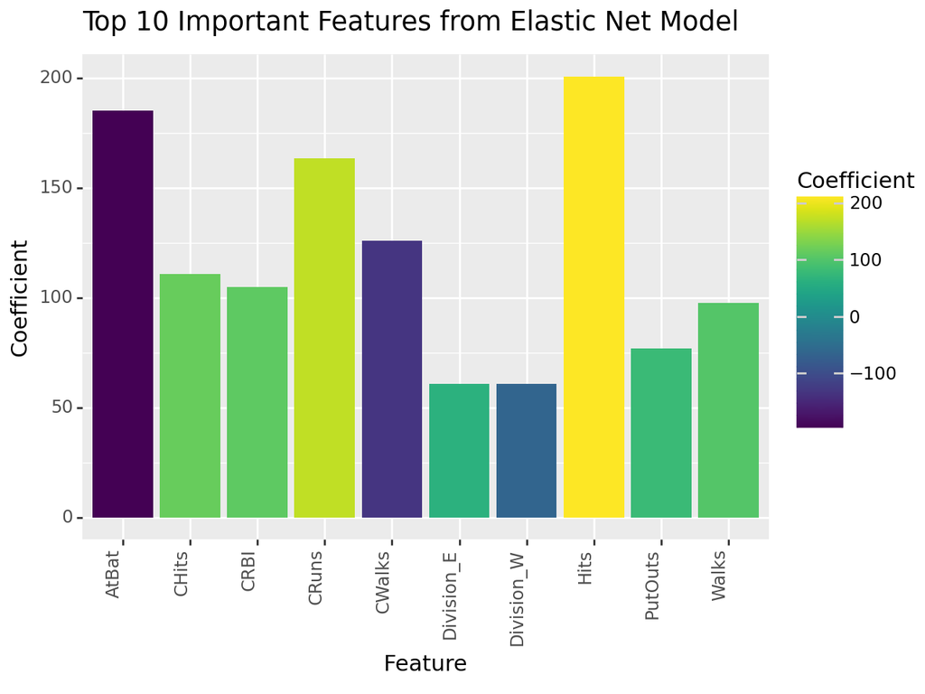

```python
# Now create a plot with plotnine
plot = (ggplot(df_top10_coefs,aes(x='Feature', y='Absolute Coefficient', fill='Coefficient'))
        + geom_bar(stat='identity')   # Use 'identity' to tell plotnine that y values are already calculated
        + theme(axis_text_x=element_text(rotation=90, hjust=1))   # Rotate x axis labels for readability
        + labs(title='Top 10 Important Features from Elastic Net Model', y='Coefficient', x='Feature')
        + theme(legend_title=element_text(text='Coefficient')))

# Display the plot
print(plot)
```